# Global Ecology Digest from May 13, 2026 to May 27, 2026

##### 📄 Safeguarding human roles in conservation science in the age of AI ✨ AI title

Shared by **Pablo Garcia-Diaz** [@pablo-ecology.bsky.social](https://bsky.app/profile/pablo-ecology.bsky.social) · 2026-05-21 · 💚 6 likes on Bluesky

[output not shown]

**link:** https://www.sciencedirect.com/science/article/pii/S0006320726002041  
[View Original Post on Bluesky](https://bsky.app/profile/did:plc:jvl2oy4s2hpizxkbd7ngq7ty/post/3mmf4ddrknc2q)↑ Up

[output not shown]

[figure not shown]

##### 📄 Enduring cultural legacies affect Euro-American wildlife values

Shared by **Pablo Garcia-Diaz** [@pablo-ecology.bsky.social](https://bsky.app/profile/pablo-ecology.bsky.social) · 2026-05-21 · 💚 7 likes on Bluesky

[output not shown]

**link:** https://www.nature.com/articles/s41893-026-01825-8  
[View Original Post on Bluesky](https://bsky.app/profile/did:plc:jvl2oy4s2hpizxkbd7ngq7ty/post/3mmf422rrkc27)↑ Up

[output not shown]

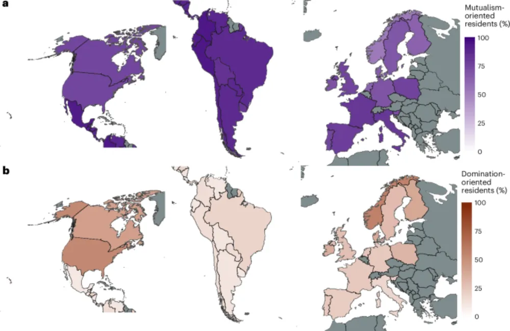

##### 📄 Greenland Institute of Natural Resources seeks a Postdoctoral Researcher with experience in vegetation mapping and herbivory.

Shared by **Brian J. Enquist** [@bjenquist.bsky.social](https://bsky.app/profile/bjenquist.bsky.social) · 2026-05-20 · 💚 15 likes on Bluesky

[output not shown]

**link:** https://naalakkersuisut.emply.net/recruitment/vacancyAd.aspx?publishingId=52944607-ef05-471b-b36c-5cd4ba2071d3&languageKey=en-GB  
[View Original Post on Bluesky](https://bsky.app/profile/did:plc:rca6ykp24ubm3alkgmcblslc/post/3mmcg3sstds2b)↑ Up

[output not shown]

[figure not shown]

##### 📄 Chemical timber tracing: combining tree-genera information lowers reference data needs and makes harvest location identification more accurate

Shared by **Pieter Zuidema** [@pieterzuidema.bsky.social](https://bsky.app/profile/pieterzuidema.bsky.social) · 2026-05-20 · 💚 8 likes on Bluesky

[output not shown]

**link:** https://link.springer.com/article/10.1186/s13595-026-01341-x  
[View Original Post on Bluesky](https://bsky.app/profile/did:plc:dkwchij2aqfq2mngtbzbes2n/post/3mmbz7pe5dk22)↑ Up

[output not shown]

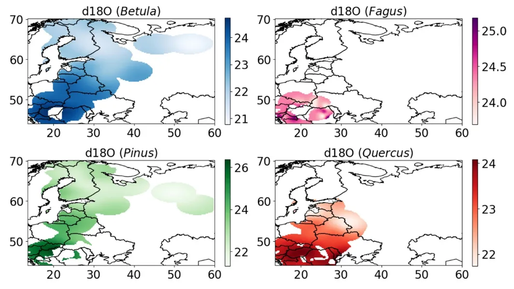

##### 📄 [FRB-CESAB] CESABINARs - Fondation pour la recherche sur la biodiversité

Shared by **FRB｜Fondation pour la recherche sur la biodiversité** [@frbiodiv.bsky.social](https://bsky.app/profile/frbiodiv.bsky.social) · 2026-05-20 · 💚 5 likes on Bluesky

[output not shown]

**link:** https://bit.ly/40zrT7v  
[View Original Post on Bluesky](https://bsky.app/profile/did:plc:niursuowepii6gcvzzwhupfn/post/3mmbvx7vcck2j)↑ Up

[output not shown]

[figure not shown]

##### 📄 Building the Infrastructure for Reproducible Biodiversity Science

Shared by **Brian J. Enquist** [@bjenquist.bsky.social](https://bsky.app/profile/bjenquist.bsky.social) · 2026-05-20 · 💚 15 likes on Bluesky

[output not shown]

**link:** https://methodsblog.com/2026/03/30/building-the-infrastructure-for-reproducible-biodiversity-science/  
[View Original Post on Bluesky](https://bsky.app/profile/did:plc:rca6ykp24ubm3alkgmcblslc/post/3mmbtmax2rk2o)↑ Up

[output not shown]

[figure not shown]

##### 📄 Global Ecology Vol. 3

Shared by **Nicolas Mouquet** [@nmouquet.bsky.social](https://bsky.app/profile/nmouquet.bsky.social) · 2026-05-20 · 💚 13 likes on Bluesky

[output not shown]

**link:** https://go.bsky.app/MkLHiKU  
[View Original Post on Bluesky](https://bsky.app/profile/did:plc:ppsghcl5bbpgjcljnhra353s/post/3mmbt6f2ju22i)↑ Up

[output not shown]

[figure not shown]

##### 📄 The Origin of Life in the Light of Evolution

Shared by **Ricard Solé** [@ricardsole.bsky.social](https://bsky.app/profile/ricardsole.bsky.social) · 2026-05-19 · 💚 43 likes on Bluesky

[output not shown]

**link:** https://arxiv.org/abs/2605.05464  
[View Original Post on Bluesky](https://bsky.app/profile/did:plc:pghayd3bor4lqoum3o6sgcxf/post/3mmaighjdcs2g)↑ Up

[output not shown]

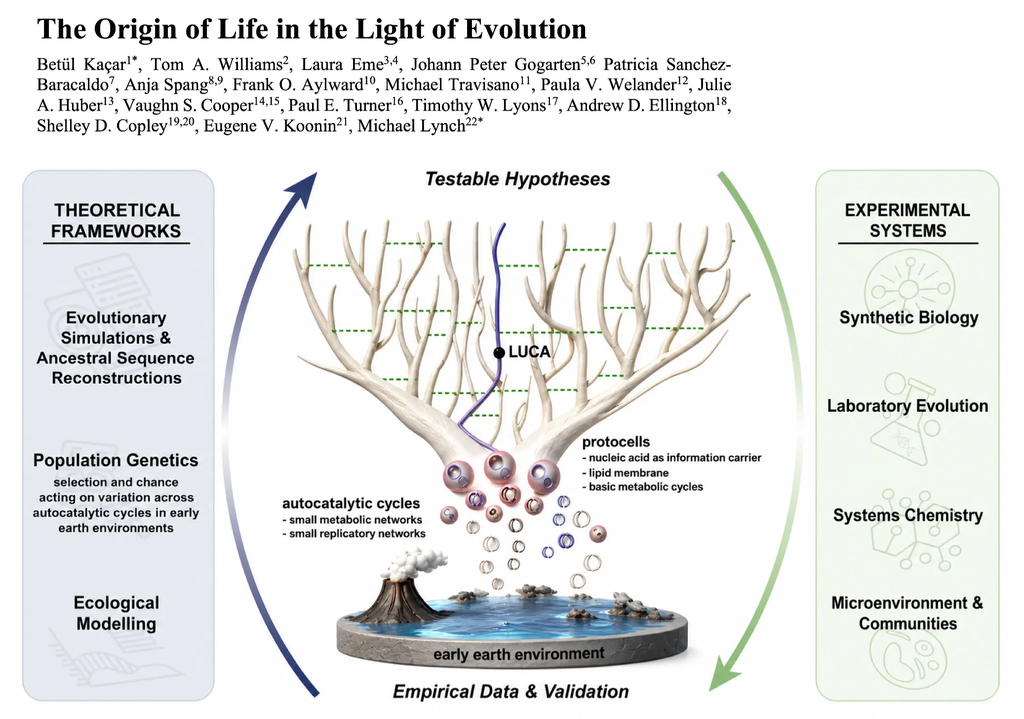

##### 📄 Global taxon-stratified high-resolution GBIF sampling-effort dataset for bias-aware SDMs ✨ AI title

Shared by **Ahmed El-Gabbas** [@ahmed-elgabbas.bsky.social](https://bsky.app/profile/ahmed-elgabbas.bsky.social) · 2026-05-19 · 💚 2 likes on Bluesky

[output not shown]

**link:** https://doi.org/10.1111/ddi.70205  
[View Original Post on Bluesky](https://bsky.app/profile/did:plc:m4ilafth4dpjqoni6unlrkb4/post/3mm7kwbnnbc2s)↑ Up

[output not shown]

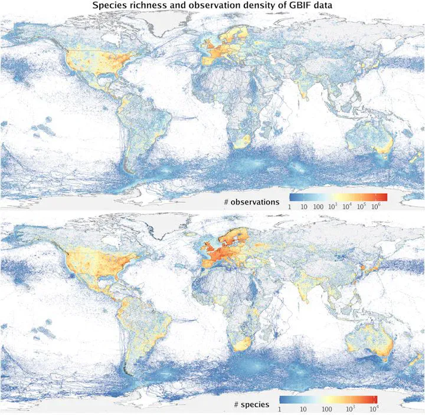

##### 📄 Scaling laws for functional diversity and specialization across complex systems ✨ AI title

Shared by **Brian J. Enquist** [@bjenquist.bsky.social](https://bsky.app/profile/bjenquist.bsky.social) · 2026-05-19 · 💚 18 likes on Bluesky

[output not shown]

**link:** https://www.pnas.org/doi/10.1073/pnas.2509729123  
[View Original Post on Bluesky](https://bsky.app/profile/did:plc:rca6ykp24ubm3alkgmcblslc/post/3mm7cvqeauc26)↑ Up

[output not shown]

[figure not shown]

##### 📄 Atlas of Botany Discussion & Book Signing

Shared by **Jess Rickenback** [@jess-rickenback.bsky.social](https://bsky.app/profile/jess-rickenback.bsky.social) · 2026-05-19 · 💚 10 likes on Bluesky

[output not shown]

**link:** https://rbgeshop.org/products/atlas-of-botany-book-signing?pr_prod_strat=e5_desc&pr_rec_id=5c4328909&pr_rec_pid=15862224388469&pr_ref_pid=15710013325685&pr_seq=uniform  
[View Original Post on Bluesky](https://bsky.app/profile/did:plc:siieb5m57znytybo22elbkjh/post/3mm7bpamxsc2h)↑ Up

[output not shown]

[figure not shown]

##### 📄 Higher and more stable biological control of herbivores in diversified strip cropping systems ✨ AI title

Shared by **Brian J. Enquist** [@bjenquist.bsky.social](https://bsky.app/profile/bjenquist.bsky.social) · 2026-05-19 · 💚 13 likes on Bluesky

[output not shown]

**link:** https://besjournals.onlinelibrary.wiley.com/doi/10.1111/1365-2664.70381  
[View Original Post on Bluesky](https://bsky.app/profile/did:plc:rca6ykp24ubm3alkgmcblslc/post/3mm7235zn7c2b)↑ Up

[output not shown]

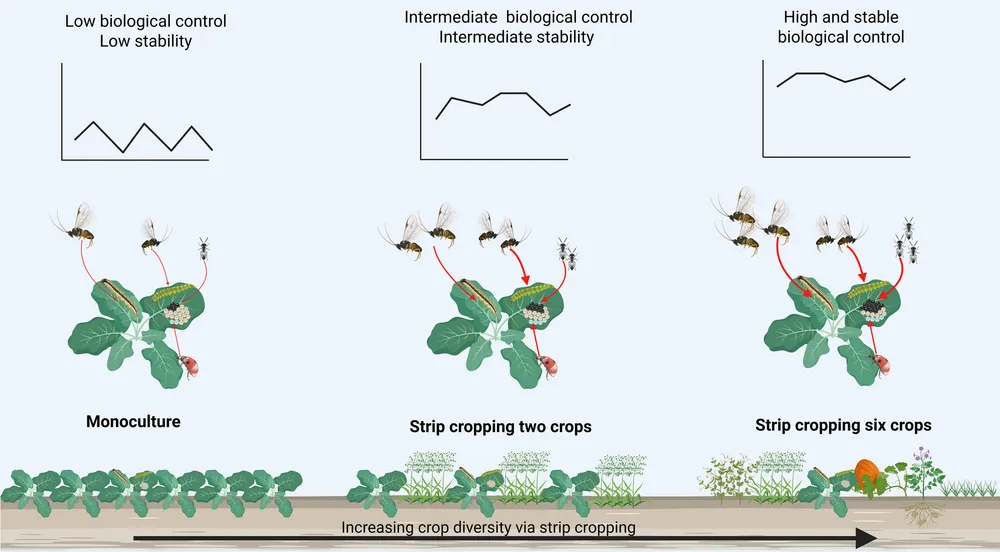

##### 📄 Symbiotic bacteria may support calcium carbonate precipitation in the Gulf toadfish

Shared by **PLOS Biology** [@plosbiology.org](https://bsky.app/profile/plosbiology.org) · 2026-05-19 · 💚 14 likes on Bluesky

[output not shown]

**link:** https://plos.io/49aY5SH  
[View Original Post on Bluesky](https://bsky.app/profile/did:plc:5522ztebtekoor5efelihqhb/post/3mm6vzmoefs2s)↑ Up

[output not shown]

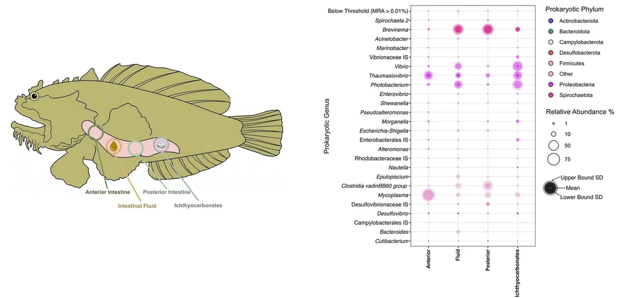

##### 📄 Population density shapes home range size and overlap in animal movement ✨ AI title

Shared by **Luca Santini** [@lsantinieco.bsky.social](https://bsky.app/profile/lsantinieco.bsky.social) · 2026-05-19 · 💚 12 likes on Bluesky

[output not shown]

**link:** https://nsojournals.onlinelibrary.wiley.com/doi/10.1002/ecog.07936  
[View Original Post on Bluesky](https://bsky.app/profile/did:plc:uklfqjiv2ymojvoa4x3fnqnt/post/3mm6r4dznps2q)↑ Up

[output not shown]

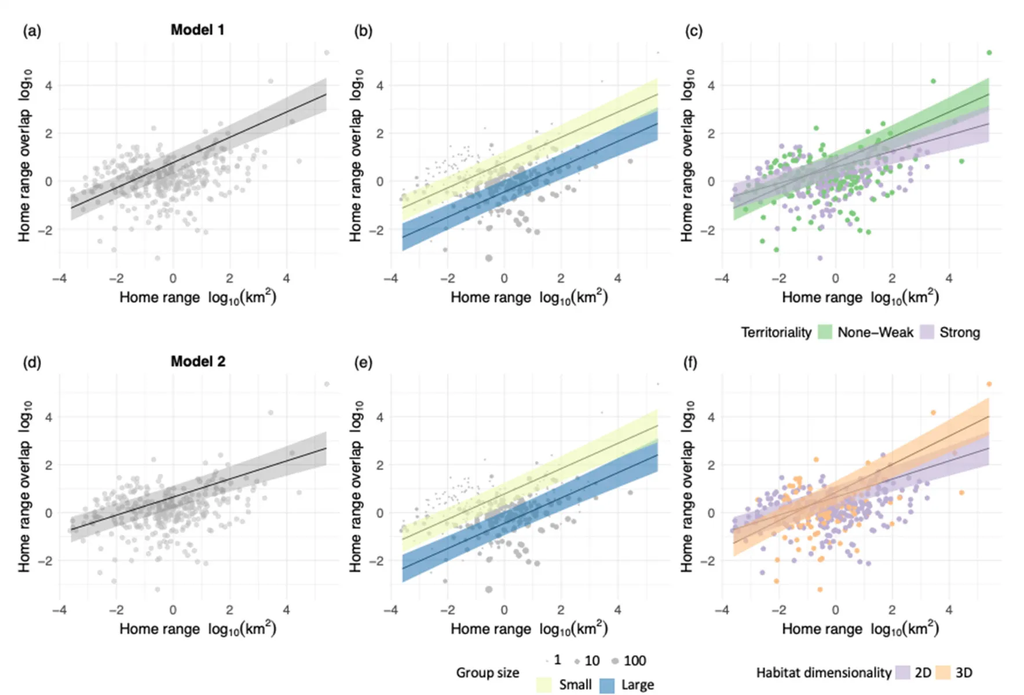

##### 📄 May 2026 Funk Biogeography Seminar — Michael Landis

Shared by **The International Biogeography Society** [@biogeography.bsky.social](https://bsky.app/profile/biogeography.bsky.social) · 2026-05-18 · 💚 27 likes on Bluesky

[output not shown]

**link:** https://www.biogeography.org/news/news/may-2026-funk-biogeography-seminar-michael-landis/  
[View Original Post on Bluesky](https://bsky.app/profile/did:plc:3ggu2dvau7qi4ptkdynzho3x/post/3mm5jbni4ac2p)↑ Up

[output not shown]

[figure not shown]

##### 📄 Alpine shrubification documented across European mountains using GLORIA network data ✨ AI title

Shared by **Dr. Mariana García Criado** [@nanitundra.bsky.social](https://bsky.app/profile/nanitundra.bsky.social) · 2026-05-18 · 💚 5 likes on Bluesky

[output not shown]

**link:** http://dx.doi.org/10.1111/gcb.70922  
[View Original Post on Bluesky](https://bsky.app/profile/did:plc:aqbuq4s7636ofwdji3vjafqm/post/3mm57j53un226)↑ Up

[output not shown]

[figure not shown]

##### 📄 An underground census: what bacteria and fungi tell us about ecosystem health – Soil & Landscape Science Lab

Shared by **Raphael Viscarra Rossel** [@ravr19.bsky.social](https://bsky.app/profile/ravr19.bsky.social) · 2026-05-18 · 💚 8 likes on Bluesky

[output not shown]

**link:** https://ravr19.github.io/slsl_blog/posts/2026-05-18-bactfung/  
[View Original Post on Bluesky](https://bsky.app/profile/did:plc:v66fqvnkwos7gwuivu4wzgs5/post/3mm56qymdak2b)↑ Up

[output not shown]

[figure not shown]

##### 📄 Ecological role of emergent properties in the chemodiversity landscape

Shared by **Robin Heinen** [@robinheinennl.bsky.social](https://bsky.app/profile/robinheinennl.bsky.social) · 2026-05-18 · 💚 54 likes on Bluesky

[output not shown]

**link:** https://doi.org/10.1038/s41559-026-03057-7  
[View Original Post on Bluesky](https://bsky.app/profile/did:plc:jggts57ydp66iwg2pbddu4n5/post/3mm4z7w7lnc2f)↑ Up

[output not shown]

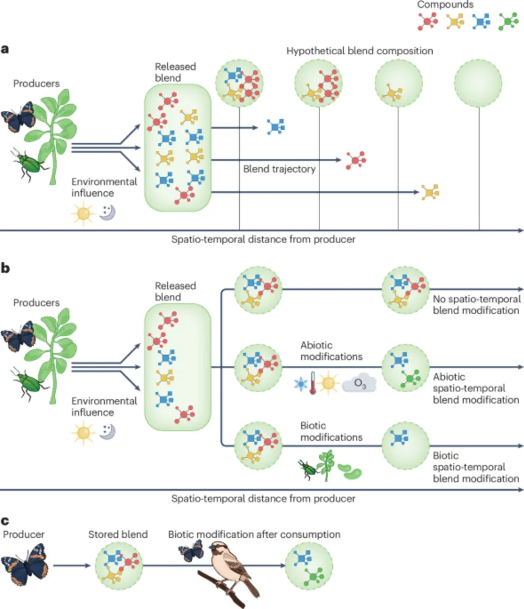

🏠 Back to home · 📚 All digests

[figure not shown]

This page is maintained by [Nicolas Mouquet](http://nicolasmouquet.free.fr/)